# Deques

Deque atau Double Ended Queue adalah versi umum dari struktur data Queue yang memungkinkan penyisipan dan penghapusan di kedua ujungnya. Berikut adalah contoh program deque dalam berbagai bahasa.

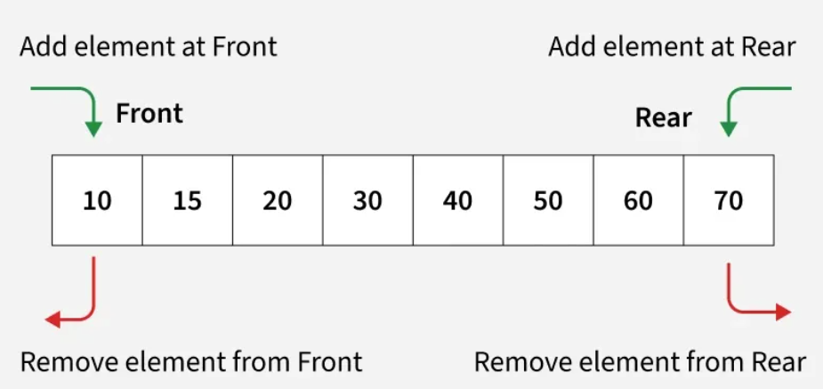

Operasi-operasi yang terdapat pada Deques antara lain :

- deque (), inisialisasi struktur data deque kosong
- addFront (data), penambahan data baru di ujung front pada deque
- addRear (data), penambahan data baru di ujung rear pada deque
- removeRear (), penghapusan data pada ujung rear
- removeFront (), penghapusan data pada ujung front
- isEmpty(), pengecekan apakah deque dalam keadaan kosong
- size (), informasi jumlah data yang terdapat pada deque

Struktur data Deques ini direpresentasikan dengan List, dimana: indeks awal list, yaitu indeks ke-0, adalah posisi front pada deques indeks akhir list, yaitu indeks terakhir, adalah posisi rear pada deques Oleh karena itu, penambahan data baru pada posisi front dapat dilakukan dengan method insert() pada posisi ke-0. Sedangkan penambahan data baru pada posisi rear dapat dilakukan dengan method append , yang merupakan penambahan data baru pada list di posisi terakhir. Sedangkan penghapusan data pada posisi front dapat dilakukan dengan method pop() pada posisi ke-0, sedangkan penghapusan data pada posisi rear dilakukan dengan method pop()

```python
def createDeque():
    d=[]
    return (d)
def addFront(d,data):
    d.insert(0,data)
    return(d)
def addRear(d,data):
    d.append(data)
    return(d)
def removeRear(d):
    data=d.pop()
    return(data)
def removeFront(d):
    data=d.pop(0)
    return(data)
def isEmpty(d):
    return (d==[])
def size(d):
    return (len(d))
```

```python
deq=createDeque()
```

```python
addFront(deq,'struktur')
addFront(deq,'data')
```

```
['data', 'struktur']
```

```python
addRear(deq,'2018')
addRear(deq,'2019')
```

```
['data', 'struktur', '2018', '2019']
```

```python
addRear(deq,'100')
```

```
['data', 'struktur', '2018', '2019', '100']
```

```python
data=removeFront(deq)
print(data)
print(deq)
```

```
data
['struktur', '2018', '2019', '100']
```

```python
data=removeRear(deq)
print(data)
print(deq)
```

```
100
['struktur', '2018', '2019']
```

```python
size(deq)
```

```
3
```

```python
isEmpty(deq)
```

```
False
```

```python
addRear(deq,removeFront(deq))
print(deq)
```

```
['2018', '2019', 'struktur']
```

### Implementasi Deques

```python
stack_asli = [10, 3, 5, 8, 12, 7, 4]
print(f"Stack Awal: {stack_asli}")

jumlah_genap = 0
stack_sementara = []

while len(stack_asli) > 0:
    elemen = stack_asli.pop()

    if elemen % 2 == 0:
        jumlah_genap += 1

    stack_sementara.append(elemen)

while len(stack_sementara) > 0:
    stack_asli.append(stack_sementara.pop())

print("-" * 40)
print(f"Total elemen genap  : {jumlah_genap}")
print(f"Stack Akhir (utuh)  : {stack_asli}")
```

```
Stack Awal: [10, 3, 5, 8, 12, 7, 4]
----------------------------------------
Total elemen genap  : 4
Stack Akhir (utuh)  : [10, 3, 5, 8, 12, 7, 4]
```

```python
from collections import deque

def cek_palindrome(teks):
    teks_bersih = teks.lower().replace(" ", "")

    dq = deque(teks_bersih)

    while len(dq) > 1:
        huruf_depan = dq.popleft()
        huruf_belakang = dq.pop()

        if huruf_depan != huruf_belakang:
            return False

    return True


daftar_kata = [
    "katak",
    "malam",
    "kasur rusak",
    "python",
    "A nut for a jar of tuna"
]

print("=== HASIL CEK PALINDROME ===")
for kata in daftar_kata:
    if cek_palindrome(kata):
        print(f"'{kata}' -> ✅ Palindrome")
    else:
        print(f"'{kata}' -> ❌ BUKAN Palindrome")
```

```
=== HASIL CEK PALINDROME ===
'katak' -> ✅ Palindrome
'malam' -> ✅ Palindrome
'kasur rusak' -> ✅ Palindrome
'python' -> ❌ BUKAN Palindrome
'A nut for a jar of tuna' -> ✅ Palindrome
```

```python
# --- DEFINISI FUNGSI DEQUE ---
def createDeque():
    return []

def addRear(dq, item):
    dq.append(item)

def removeRear(dq):
    return dq.pop()

def removeFront(dq):
    return dq.pop(0)

def size(dq):
    return len(dq)

# --- KODE ANDA YANG SUDAH DIRAPIKAN ---
def cekPalindrom(string):
    palindrom = createDeque()
    for huruf in string:
        addRear(palindrom, huruf)

    cek = True
    while size(palindrom) > 1:
        a = removeRear(palindrom)
        b = removeFront(palindrom)

        if a != b:
            # Begitu nemu yang beda, langsung set False dan hentikan loop (break)
            cek = False
            break

    return cek

print(cekPalindrom('hannah'))
print(cekPalindrom('surabaya'))
print(cekPalindrom('abcdcba'))  # Output: True
print(cekPalindrom('katak'))    # Output: True
print(cekPalindrom('taat'))     # Output: True
print(cekPalindrom('dia'))      # Output: False
```

```
True
False
True
True
True
False
```

```python
def simulasi_undo():
    # Inisialisasi stack kosong
    stack = []

    aksi_input = [("ketik", "A"), ("ketik", "B"), ("ketik", "C"), ("undo",)]

    print("Memulai simulasi...")

    for aksi in aksi_input:
        perintah = aksi[0]

        if perintah == "ketik":
            karakter = aksi[1]
            stack.append(karakter)  # Operasi PUSH
            print(f"Aksi: Ketik '{karakter}' -> Isi Stack saat ini: {stack}")

        elif perintah == "undo":
            if len(stack) > 0:
                terhapus = stack.pop()  # Operasi POP
                print(f"Aksi: Undo -> Menghapus '{terhapus}'. Isi Stack saat ini: {stack}")
            else:
                print("Aksi: Undo -> Gagal, stack kosong!")

    output_akhir = "".join(stack)
    print("\n" + "="*20)
    print(f"Output akhir: {output_akhir}")
    print("="*20)

# Menjalankan program
if __name__ == "__main__":
    simulasi_undo()
```

```
Memulai simulasi...
Aksi: Ketik 'A' -> Isi Stack saat ini: ['A']
Aksi: Ketik 'B' -> Isi Stack saat ini: ['A', 'B']
Aksi: Ketik 'C' -> Isi Stack saat ini: ['A', 'B', 'C']
Aksi: Undo -> Menghapus 'C'. Isi Stack saat ini: ['A', 'B']

====================
Output akhir: AB
====================
```